# ParkSmart for Responsive Parking in San Francisco

Yanbing Zhao, Chenxi Zhu

December 16, 2022

```r
options(scipen=10000000)

library(tidyverse)
library(kableExtra)
library(caret)
library(knitr)
library(pscl)
library(plotROC)
library(pROC)
library(lubridate)
library(tidycensus)
library(broom)
library(RSocrata)
library(sf)
library(riem)
library(gridExtra)
library(viridis)
library(spatstat)
library(raster)
library(spdep)
library(FNN)
library(grid)
library(classInt)
# library(patchwork)
library(ggplot2)
library(gganimate)
library(hms)
library(gifski)
library(stargazer)

# data directory
source("https://raw.githubusercontent.com/urbanSpatial/Public-Policy-Analytics-Landing/master/functions.r")

# root.dir = "https://raw.githubusercontent.com/urbanSpatial/Public-Policy-Analytics-Landing/master/DATA/"
# subsidy <- read.csv(file.path(root.dir,"/Chapter6/housingSubsidy.csv"))

palette5 <- c("#981FAC","#CB0F8B","#FF006A","#FE4C35","#FE9900")
palette4 <- c("#981FAC","#FF006A","#FE4C35","#FE9900")
palette2 <- c("#981FAC","#FF006A")
```

[Link](https://youtu.be/ob2G1WK1aRo) to video presentation.

The analysis below is a new iteration with some discrepancies to the video presentation.

## 1. Introduction

San Francisco is the fourth most populous city in California and is known for its vibrant economy and cultural scene. The city covers a land area of 46.9 square miles and has a population of 815,201 as of 2021. San Francisco is considered the commercial, financial, and cultural center of northern California. It is also one of the most densely populated cities in the United States, with a per capita income of $160,749 as of 2021.

San Francisco is home to a thriving economy, with a particular focus on the technology industry. The city is home to many major tech companies, such as Twitter, Uber, and Salesforce, as well as being a hub for startups and innovation. In addition to the technology sector, San Francisco also has a strong financial industry, with many banks and financial institutions based in the city. The city’s economy also benefits from a strong tourism industry, with many visitors drawn to its iconic landmarks and vibrant culture

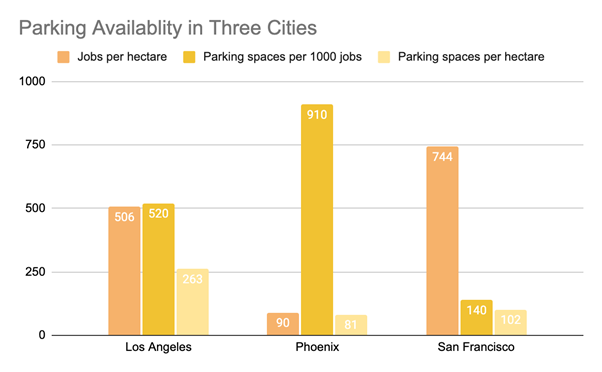

*source: Erick Guerra [Lecture Slides]*

Downtown San Francisco is relatively dense compared to other south western cities. Among Phoenix and Los Angeles, San Francisco have the highest number of jobs per hectare with the lowest number of parking spaces per 1000 jobs. This really makes parking extremely difficult; and as a result of that, drivers tend to cruise around the block looking for available parking spaces. Cruising behaviour is not ideal to transportation planners because this will exacerbate the already terrible traffic problems in San Francisco.

San Francisco is a highly congested city, with traffic often causing delays and inconvenience for drivers. According to INRIX’s global traffic index, just before the COVID-19 pandemic, San Francisco was ranked the 7th most congested city in the United States. This congestion is costly for the city, with estimates suggesting that it costs San Francisco approximately $3 billion annually. One of the main contributors to this congestion is the high number of drivers on the roads who are looking for a parking spot. This behavior, known as cruising, can contribute to congestion and make traffic problems worse. In addition to the direct costs associated with congestion, such as lost productivity and fuel consumption, it can also have negative impacts on the environment and public health, through increased air pollution and the risk of vehicular accidents. As such, it is important for transportation planners to find ways to reduce congestion and improve the flow of traffic in the city.

The San Francisco Municipal Transportation Agency (SFMTA) has implemented various measures to address the problem of traffic congestion and cruising behavior in the city. One such measure is the use of dynamic pricing for parking, which involves adjusting parking rates based on demand in order to encourage more efficient use of parking spaces. In 2011, the SFMTA launched a program called SFpark, which is a pioneering dynamic pricing program that adjusts parking rates in real-time based on demand, with the aim of maintaining an occupancy rate of around 85% for all parking spaces. The idea behind this program is that by ensuring there is always an available parking space for drivers who need to park, it will reduce the amount of time drivers spend cruising around looking for a space and ultimately help to alleviate congestion on the roads.

## 2. Use Case and Objectives

### 2.1 Use Case

This project aims to help the SFMTA predict the demand for parking in specific areas and adjust parking rates accordingly. The goal is to make the pricing of parking more responsive to actual demand, rather than being fixed or based on a predetermined schedule. By raising the hourly rates for parking in areas where demand is high, the SFMTA hopes to discourage cruising behavior and reduce congestion on the roads. This, in turn, can help mitigate the negative externalities of congestion, such as air pollution, increased risk of vehicular accidents, and unnecessary fuel consumption. By adjusting the parking rates in advance, the SFMTA can also help prevent a surplus of parking demand and ease congestion in high demand areas. Overall, this new pricing scheme is intended to help the SFMTA better manage parking demand and improve the flow of traffic in the city.

The pricing scheme will be adjusted per month. The idea is to use the first three weeks of parking data in a month coupled with fixed spatial, temporal, pricing, and weather features to predict the final week’s parking demand and adjust rates accordingly. Then we will wait for the market to respond and catch up on the new prices and perform a new iteration for the next month. Prediction model based on linear regression is used here to approximate real-time parking demand. Instead of directly using past data on parking for a proxy for future demand, we want to incorporate the fixed spatial effects, weather forecast data, and temporal effects to mimic real-time street parking occupancy and input different pricing scheme to control parking demand.

### 2.2. Objectives

The goal of this model is to accurately predict the demand for parking in downtown San Francisco. This prediction can be used to inform the development of an app that helps traffic administrators at the SFMTA manage congestion and optimize parking occupancy. The app will provide a dashboard that allows admins to monitor parking in real-time and make bulk adjustments as needed to help alleviate congestion and ensure that parking spaces are used efficiently. The app is intended to be a tool that helps traffic admins at SFMTA better understand and manage parking demand, ultimately improving the overall flow of traffic in the area and reducing the impact of parking-related issues on the community.

## 3. Data

### 3.1 Dependent Variables

Out unit of analysis for calculating parking demand is per hour and per street segment. For the calculation, we downloaded the following datasets:

**SFMTA Parking Meter Detailed Revenue Transaction** [obtained from [DataSF](https://data.sfgov.org/Transportation/SFMTA-Parking-Meter-Detailed-Revenue-Transactions/imvp-dq3v)]: In the parking meter transaction records, each row equals a single transaction by a single customer at a single meter. Subsequent transactions by a customer to extend time, for example, are captured as new transaction record and indicated with a METER_EVENT_TYPE of AT (Additional Time).

**Parking Meters** [obtained form [DataSF](https://data.sfgov.org/Transportation/Parking-Meters/8vzz-qzz9)]: Location, cap color and other key attributes of parking meters in San Francisco.

**Street Segments** [obtained from [DataSF](https://data.sfgov.org/Transportation/Speed-Limits-per-Street-Segment/3t7b-gebn)]: Each street segment is defined as the portion of the street between the two closets intersections.

```r
epsg <- 'EPSG:6419'
district <- st_read("data/Planning Districts.geojson") %>% filter(district == "Downtown") %>%
  st_transform(epsg)

# collect downtown meters and transactions only
meter <- read.csv("data/Parking_Meters.csv") %>%
  st_as_sf(coords = c("LONGITUDE", "LATITUDE"), crs = 4326, agr = "constant") %>%
  st_transform(epsg)# %>%
  # st_join(., district) %>%
  # filter(!is.na(district))

street <- st_read("data/Speed Limits per Street Segment.geojson") %>%
  st_transform(epsg) %>%
  st_join(., district) %>%
  filter(!is.na(district))
street$max.occ <- round(as.numeric(st_length(street)/5.5*2))

# time_frame <- tran
transaction <- read.csv("data/transaction_january_downtown.csv")
transaction <- transaction[transaction$post_id %in% meter$POST_ID, ] %>%
  mutate(interval60 = floor_date(ymd_hms(session_end_dt), unit = "1 hour"))

read_transaction <- FALSE
if (read_transaction){
  transaction <- read.socrata("https://data.sfgov.org/resource/imvp-dq3v.json?$where=session_start_dt between '2022-01-03T12:00:00' and '2022-01-23T12:00:00'")
  transaction <- transaction[transaction$post_id %in% meter$POST_ID, ]}

# index table to connect block - street id - post id
idx <- read.csv("data/index_table.csv")

# rate area
rate <- read.csv("data/price_area - Copy.csv")

street <- street %>%
  merge(rate, by="ST_ID") %>%
  rename(rate_area = OLD_RATE_AREA)
```

Visualize spatial distribution of meters in downtown. Note there is no parking meters along Market St since it is prohibited for private vehicles starting 2020.

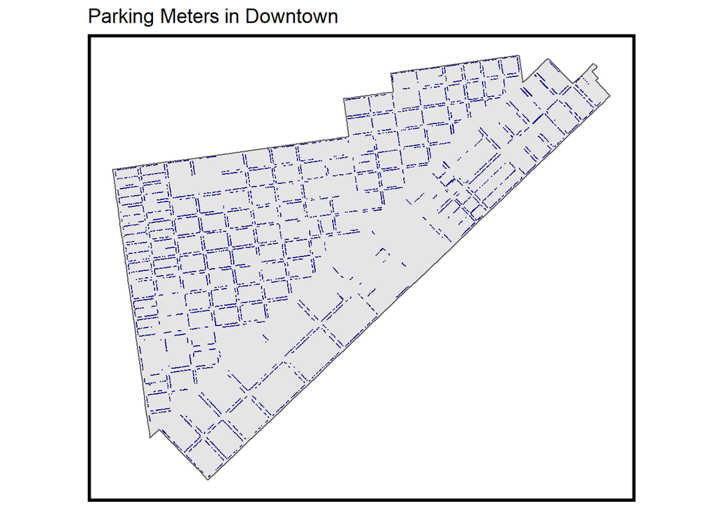

```r
ggplot() +
  geom_sf(data = district) +
  # geom_sf(data = street) +
  geom_sf(data = meter%>%st_join(., district) %>% filter(!is.na(district)), colour=plasma(8)[1], size = 0.1, show.legend = "point") +
  labs(title= "Parking Meters in Downtown") +
  mapTheme(title_size = 14)
```

**Methodology ([credit](https://github.com/mafichman/parking_estimations/blob/main/R/estimate_sf_park.R))**: To calculate the occupancy rate per hour by street segment, we assume each parking space has a three-hour parking maximum and divide the time into 1-hour interval and investigate if a spot was occupied during the time period based on meter transaction data. For each 1-hour interval, occupancy rate is calculated by dividing the total occupancy by the total number of parking spots in this street segment. The total number of parking spots is estimated using the length of the street segment assuming each parking spot takes up 18 feet in length. Then we create a hourly occupancy rate panel for each street segment. To account for drivers leaving the parking space before the time is up, the occupancy rate is capped at 100% if the rate is above 100%.

```r
dat2 <- transaction %>%
  mutate(end_interval = floor_date(ymd_hms(session_end_dt), unit = "1 hour"),
         start_interval = floor_date(ymd_hms(session_start_dt), unit = "1 hour"),
         length = end_interval - start_interval,
         tokens = as.numeric(length )/ 900 *4,
         tokens_00 = ifelse(tokens >= 1, 1, 0),
         tokens_01 = ifelse(tokens >= 2, 1, 0),
         tokens_02 = ifelse(tokens >= 3, 1, 0),
         # tokens_03 = ifelse(tokens >= 4, 1, 0),
         # tokens_04 = ifelse(tokens >= 5, 1, 0),
         # tokens_05 = ifelse(tokens >= 6, 1, 0),
         # tokens_06 = ifelse(tokens >= 7, 1, 0),
         # tokens_07 = ifelse(tokens >= 8, 1, 0),
         # tokens_08 = ifelse(tokens >= 9, 1, 0),
         # tokens_09 = ifelse(tokens >= 10, 1, 0),
         # tokens_10 = ifelse(tokens >= 11, 1, 0),
         # tokens_11 = ifelse(tokens >= 12, 1, 0)
         )

dat3 <- dat2 %>%
  group_by(start_interval, post_id) %>%
  summarize(tokens_00 = sum(tokens_00),
            tokens_01 = sum(tokens_01),
            tokens_02 = sum(tokens_02),
            # tokens_03 = sum(tokens_03),
            # tokens_04 = sum(tokens_04),
            # tokens_05 = sum(tokens_05),
            # tokens_06 = sum(tokens_06),
            # tokens_07 = sum(tokens_07),
            # tokens_08 = sum(tokens_08),
            # tokens_09 = sum(tokens_09),
            # tokens_10 = sum(tokens_10),
            # tokens_11 = sum(tokens_11)
            )

# Create a panel consisting of all the time/meter observations in the set
# Add a day of the year to each observation, join it to the transaction data
# This might need to be tinkered with to make sure every time period for every meter is included
# There are some weird one-off transactions off hours that might need to be cleaned out

study.panel <-
  expand.grid(start_interval=unique(dat3$start_interval),
              post_id = unique(dat3$post_id)) %>%
  mutate(doty = yday(start_interval)) %>%
  left_join(., dat3)

# Estimate occupancy but compiling the current tokens and the previous tokens
# that carry forward - i think (i think) the observations at 15:00 hours are the people who start
# the day parking - not every place has the same metered hours

transaction_panel <- study.panel %>%
  replace(is.na(.), 0) %>%
  arrange(start_interval) %>%
  group_by(post_id, doty) %>%
  mutate(lag01 = ifelse(is.na(lag(tokens_01)) == FALSE, lag(tokens_01), 0),
         lag02 = ifelse(is.na(lag(tokens_02)) == FALSE, lag(tokens_02), 0),
         # lag03 = ifelse(is.na(lag(tokens_03)) == FALSE, lag(tokens_03), 0),
         # lag04 = ifelse(is.na(lag(tokens_04)) == FALSE, lag(tokens_04), 0),
         # lag05 = ifelse(is.na(lag(tokens_05)) == FALSE, lag(tokens_05), 0),
         # lag06 = ifelse(is.na(lag(tokens_06)) == FALSE, lag(tokens_06), 0),
         # lag07 = ifelse(is.na(lag(tokens_07)) == FALSE, lag(tokens_07), 0),
         # lag08 = ifelse(is.na(lag(tokens_08)) == FALSE, lag(tokens_08), 0),
         # lag09 = ifelse(is.na(lag(tokens_08)) == FALSE, lag(tokens_09), 0),
         # lag10 = ifelse(is.na(lag(tokens_10)) == FALSE, lag(tokens_10), 0),
         # lag11 = ifelse(is.na(lag(tokens_11)) == FALSE, lag(tokens_11), 0)
         ) %>%
  mutate(occupancy = tokens_00 + lag01 + lag02
         # + lag03+ lag04 + lag05 +
         #   lag06 + lag07 + lag08+ lag09 + lag10 + lag11
         ) %>%
  filter(is.na(occupancy) == FALSE) %>%
  dplyr::select(start_interval, post_id, occupancy)

occ_panel <- transaction_panel %>%
  rename(POST_ID = post_id) %>%
  merge(idx, by="POST_ID") %>%
  group_by(ST_ID, doty, start_interval) %>%
  summarize(total_occupancy = sum(occupancy)) %>%
  merge(street %>% dplyr::select(ST_ID, max.occ) %>% st_drop_geometry, by="ST_ID") %>%
  mutate(occ.rate = total_occupancy/max.occ, 1)

occ_panel$occ.rate[occ_panel$occ.rate > 1 ] <- 1
```

#### Exploratory Data Analysis

To see temporal pattern of occupancy rate, we also plot the histograms of occupancy rate per street segment. We clearly have a few high occupancy periods but mostly low occupancy, indicating mostly low demand hours and a few high demand hours.

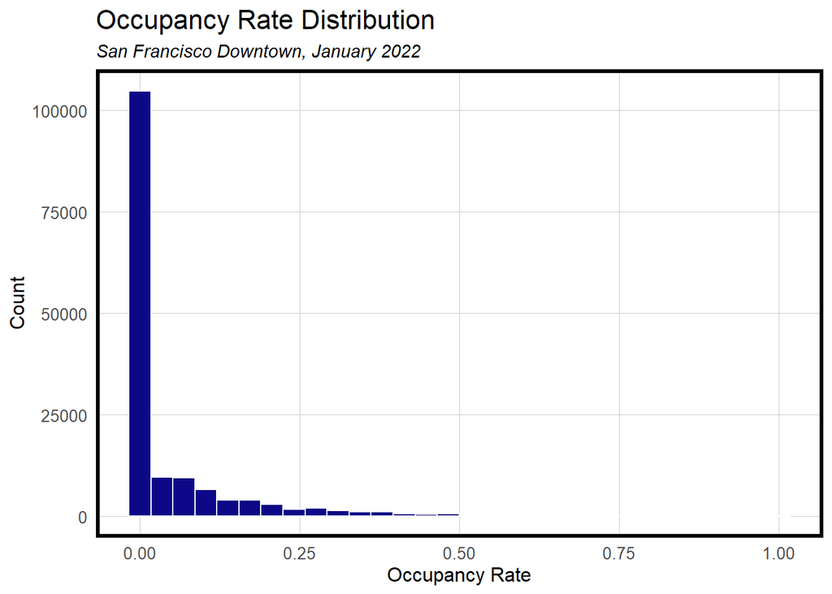

```r
ggplot(occ_panel) +
  geom_histogram(aes(x = occ.rate), color="white", fill = plasma(8)[1]) +
  labs(title = "Occupancy Rate Distribution", x = "Occupancy Rate", y = "Count", subtitle = "San Francisco Downtown, January 2022") +
  plotTheme()
```

Temporal distribution of parking demand show that Mid-day (10-15) tends to have higher occupancy. Overnight (0-7) and Night (18-24) very low occupancy with majority of parking spots not occupied since most metered parking spots provide free parking from 6pm to 9am.

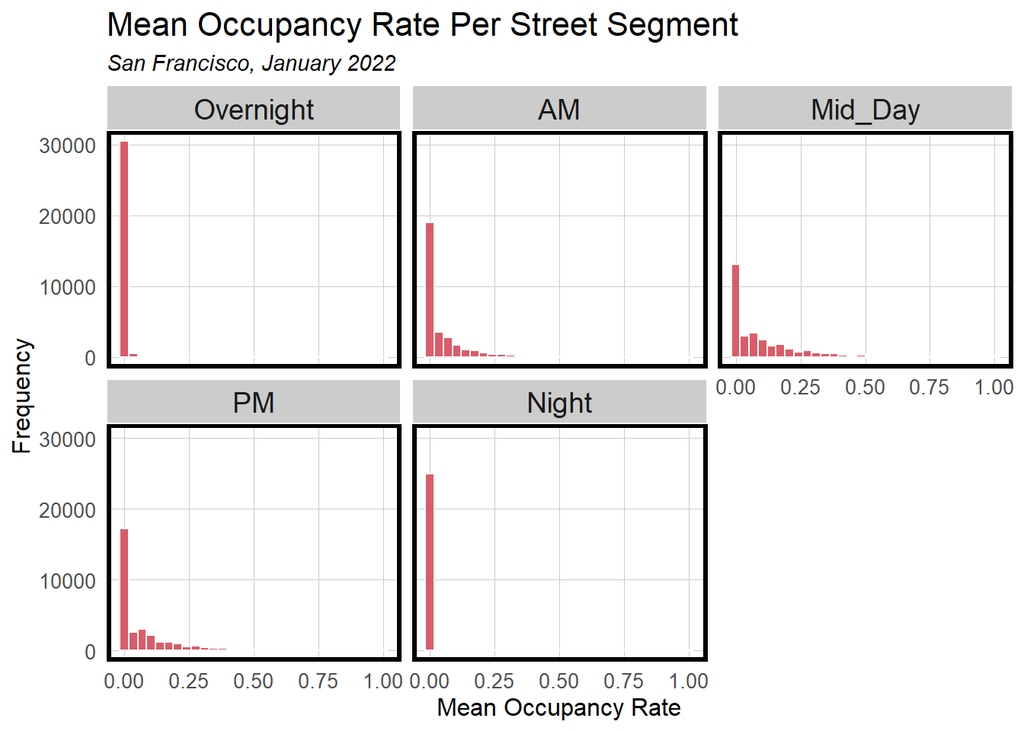

```r
# transaction_panel %>%
#   filter(interval60>= "2021-09-01 00:00:00" & interval60 <= "2021-09-30 23:59:59")%>%
#   group_by(interval60, status)%>%
#   summarise(parking_time_in_60m = sum(parking_time_in_60m))%>%
#   ggplot(aes(ymd_hms(interval60),parking_time_in_60m, colour = status))+
#     geom_line()+
#   geom_vline(data = sundays, aes(xintercept = sunday))+
#   scale_colour_manual(values = p2)+
#   labs(title="Total Parking Time by week in SF: September 2021",
#        x="Day", y="Total Parking Time (Second)") +
#   plotTheme() + theme(panel.grid.major = element_blank())

int.ampeak <- interval(as_hms("07:00:00"),as_hms("10:00:00"))
int.pmpeak <- interval(as_hms("15:00:00"),as_hms("18:00:00"))
int.midday <- interval(as_hms("10:00:00"),as_hms("15:00:00"))
int.night <- interval(as_hms("18:00:00"),as_hms("23:00:00"))
int.overnight <- interval(as_hms("00:00:00"),as_hms("07:00:00"))

panel.temporal <- occ_panel %>%
  mutate(period = case_when(ymd_hms(paste0('1970-01-01',str_sub(start_interval, 12)))%within% int.ampeak ~ "AM",
                            ymd_hms(paste0('1970-01-01',str_sub(start_interval, 12)))%within% int.pmpeak ~ "PM",
                            ymd_hms(paste0('1970-01-01',str_sub(start_interval, 12)))%within% int.midday ~ "Mid_Day",
                            ymd_hms(paste0('1970-01-01',str_sub(start_interval, 12)))%within% int.night ~ "Night",
                            ymd_hms(paste0('1970-01-01',str_sub(start_interval, 12)))%within% int.overnight ~ "Overnight"))


panel.temporal %>%
  mutate(across(period, factor, levels=c("Overnight","AM","Mid_Day","PM","Night"))) %>%
  group_by(start_interval, ST_ID, period) %>%
  summarize(mean_occupancy = mean(occ.rate))%>%
  ggplot()+
  geom_histogram(aes(mean_occupancy), color="white", fill=plasma(8)[5])+
  labs(title="Mean Occupancy Rate Per Street Segment",
       subtitle="San Francisco, January 2022",
       x="Mean Occupancy Rate",
       y="Frequency")+
  facet_wrap(~period)+
  plotTheme()
```

Temporal and spatial distribution patterns are more evident using animation. The animation shows that there are two hotspots for parking especially in the early afternoon from 1pm to 3pm, which suggests a better time-sensitive pricing scheme at the area could be needed to regulate parking demand.

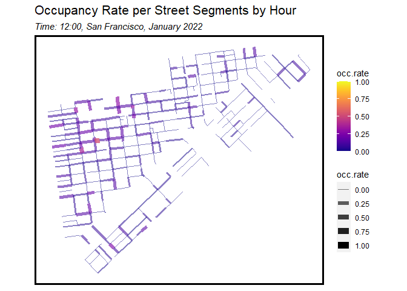

```r
panel.sf <- merge(street%>%dplyr::select(ST_ID), occ_panel, by="ST_ID") %>%
  filter(doty == 3) %>%
  mutate(hour = hour(start_interval)) %>%
  dplyr::select(ST_ID, hour, occ.rate) %>%
  st_sf() %>%
  rename(time_hour = hour)

map.lables <- qBr(panel.sf, "occ.rate")

animation =
  ggplot()+
    #geom_sf(data = sf_neighborhood, fill="#cccccc", color="#999999")+
    geom_sf(data= panel.sf,
            aes(color=occ.rate, size=occ.rate, alpha=occ.rate),
            stroke = .5, shape = 16)+
    viridis::scale_color_viridis(option = "C")+
    scale_size_continuous(range = c(0.5,4))+
    scale_alpha_continuous(range = c(0.5,1))+
    transition_manual(time_hour) +
    labs(title="Occupancy Rate per Street Segments by Hour",
         subtitle = "Time: {current_frame}:00, San Francisco, January 2022")+
    mapTheme()

# animate(animation, duration=20, renderer = gifski_renderer())
anim_save("ani.gif", height = 800, width =800, animation, duration=4, renderer = gifski_renderer())

animate(animation, duration=10, renderer = gifski_renderer())
```

### 3.2 Independent Variables and Exploratory Data Analysis

#### Weather Panel

Weather conditions such as high precipitation and high wind speed could affect driving behavior and increase parking demand. We import weather data from San Francisco airport (code SFO) and get temperature, wind speed, precipitation on an hourly basis to plot the temperature and precipitation trends over our study period.

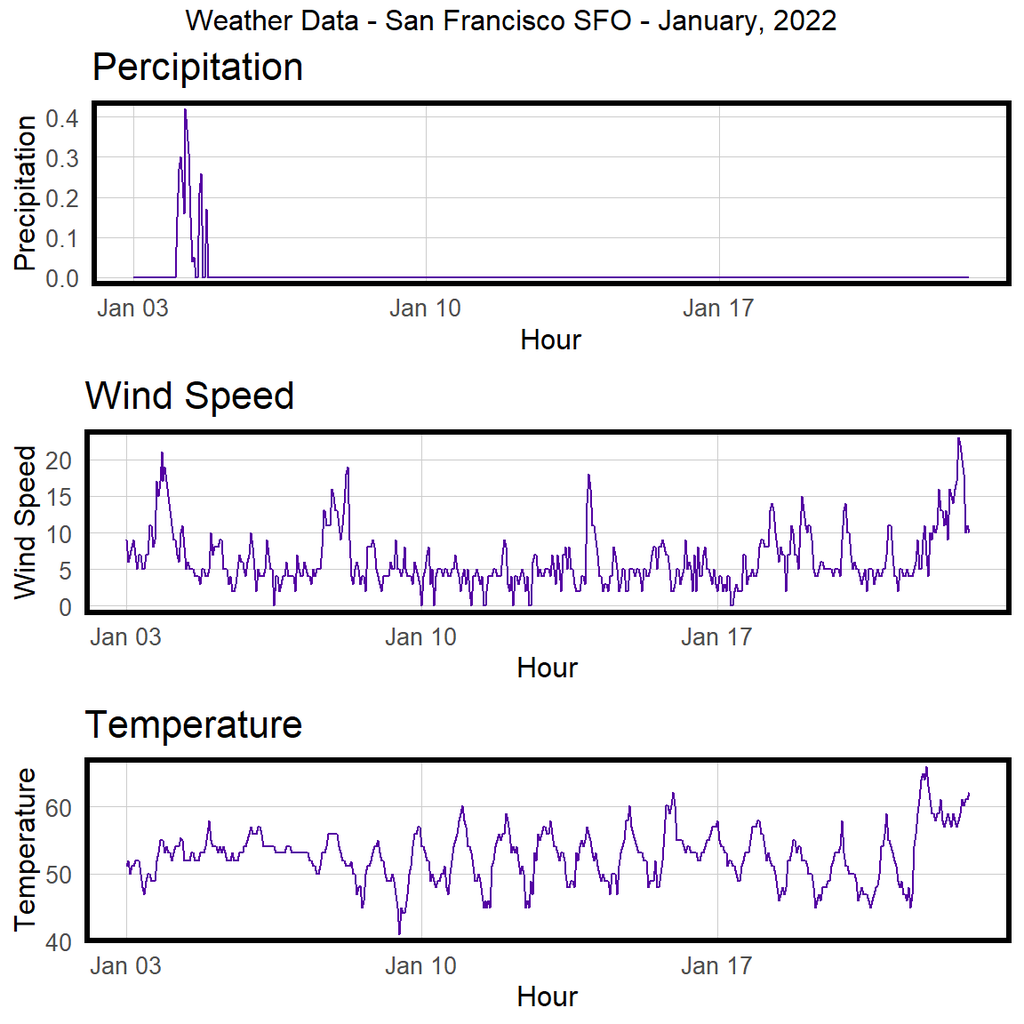

```r
weather.panel <-
  riem_measures(station = "SFO", date_start = "2022-01-03", date_end = "2022-01-23") %>%
  dplyr::select(valid, tmpf, p01i, sknt)%>%
  replace(is.na(.), 0) %>%
    mutate(start_interval = ymd_h(substr(valid,1,13))) %>%
    mutate(week = week(start_interval),
           dotw = wday(start_interval, label=TRUE)) %>%
    group_by(start_interval) %>%
    summarize(Temperature = max(tmpf),
              Precipitation = sum(p01i),
              Wind_Speed = max(sknt)) %>%
    mutate(Temperature = ifelse(Temperature == 0, 42, Temperature))

grid.arrange(top = "Weather Data - San Francisco SFO - January, 2022",
  ggplot(weather.panel, aes(start_interval, Precipitation)) + geom_line(color=plasma(8)[2]) +
    labs(title="Percipitation", x="Hour", y="Precipitation") + plotTheme(),
  ggplot(weather.panel, aes(start_interval, Wind_Speed)) + geom_line(color=plasma(8)[2]) +
    labs(title="Wind Speed", x="Hour", y="Wind Speed") + plotTheme(),
  ggplot(weather.panel, aes(start_interval, Temperature)) + geom_line(color=plasma(8)[2]) +
    labs(title="Temperature", x="Hour", y="Temperature") + plotTheme())
```

#### Amenities and Spatial Features

Relevant amenities and spatial features that might be helpful in predicting the occupancy rate of [sidewalk and street cleaning spots](https://data.sfgov.org/City-Management-and-Ethics/Street-and-Sidewalk-Cleaning/h3eg-w3pj), [carshare parking space](https://data.sfgov.org/Transportation/On-street-Carshare-Parking/g2t6-cyw6), [pedestrian safety zones](https://data.sfgov.org/Transportation/Painted-Safety-Zones/vtn2-q8ky), [parks](https://data.sfgov.org/Culture-and-Recreation/Recreation-and-Parks-Properties/gtr9-ntp6), [sidewalk widths](https://data.sfgov.org/Transportation/MTA-sidewalk_widths/4g86-grxu), [points of interests](https://data.sfgov.org/Economy-and-Community/Registered-Business-Locations-San-Francisco/g8m3-pdis) (which include registered businesses such as restaurants, retail stores, etc.), and [muni stops](https://data.sfgov.org/Transportation/Muni-Stops/i28k-bkz6). These data are downloaded from DataSF. Nearest neighbor features for parks, carshare parking spots, points of interests, and muni stops are calculated as predictors to be put into the models.

```r
# time sensitive
## sidewalk cleaning -- join to street segment
cleaning <- read.csv("data/Street_and_Sidewalk_Cleaning Count updated.csv")

# time insensitive
## pedestrian safety zone -- join to street segment, keep units
ped.safety.zone <- st_read("data/Painted Safety Zones updated.geojson") %>%
  st_transform(epsg) %>%
  st_join(., district) %>%
  filter(!is.na(district))

## park -- nn_function
park <-st_read("data/Park Lands - Recreation and Parks Department updated.geojson") %>%
  st_transform(epsg)

## on street carshare parking -- nn_function
carshare.parking <- st_read("data/On-street_Carshare_Parking updated.geojson") %>%
  st_transform(epsg)

## poi -- nn_function
poi <- st_read("data/Registered Business Locations - San Francisco updated.geojson") %>%
  st_transform(epsg)

## sidewalk width -- join to street segment, keep sidewalk_f
sidewalk.width <- read.csv("data/MTA.sidewalk_widths updated.csv")

## muni stops -- nn_function
muni <- st_read("data/Muni Stops.geojson") %>%
  st_transform(epsg)

street$park.nn <- nn_function(st_coordinates(st_centroid(street)), st_coordinates(st_centroid(park)), k = 3)
street$carshare.parking.nn <- nn_function(st_coordinates(st_centroid(street)), st_coordinates(carshare.parking), k = 3)
street$poi.nn <- nn_function(st_coordinates(st_centroid(street)), st_coordinates(poi), k = 3)
street$muni.nn <- nn_function(st_coordinates(st_centroid(street)), st_coordinates(muni), k = 3)

spatial_features <- street %>%
  st_drop_geometry() %>%
  dplyr::select(ST_ID, st_type, speedlimit, park.nn, carshare.parking.nn, poi.nn, muni.nn, max.occ, rate_area) %>%
  left_join(ped.safety.zone %>% st_drop_geometry() %>% dplyr::select(ST_ID, units), by="ST_ID") %>%
  left_join(sidewalk.width, by="ST_ID")

spatial_features$units <- as.numeric(spatial_features$units)
spatial_features$speedlimit <- as.numeric(spatial_features$speedlimit)

# spatial_features$st_type <- spatial_features$st_type %>% replace_na("unknown")
# spatial_features$units <- spatial_features$units %>% replace_na(0)
spatial_features$st_type[is.na(spatial_features$st_type)] <- "unknown"
spatial_features$units[is.na(spatial_features$units)] <- "unknown"
```

Nearest neighbor variables are introduced to account for the spatial exposure. Some of the NN variables are skewed like `park.nn` and `poi.nn`. So, log transformation is applied to get a less-skewed distribution.

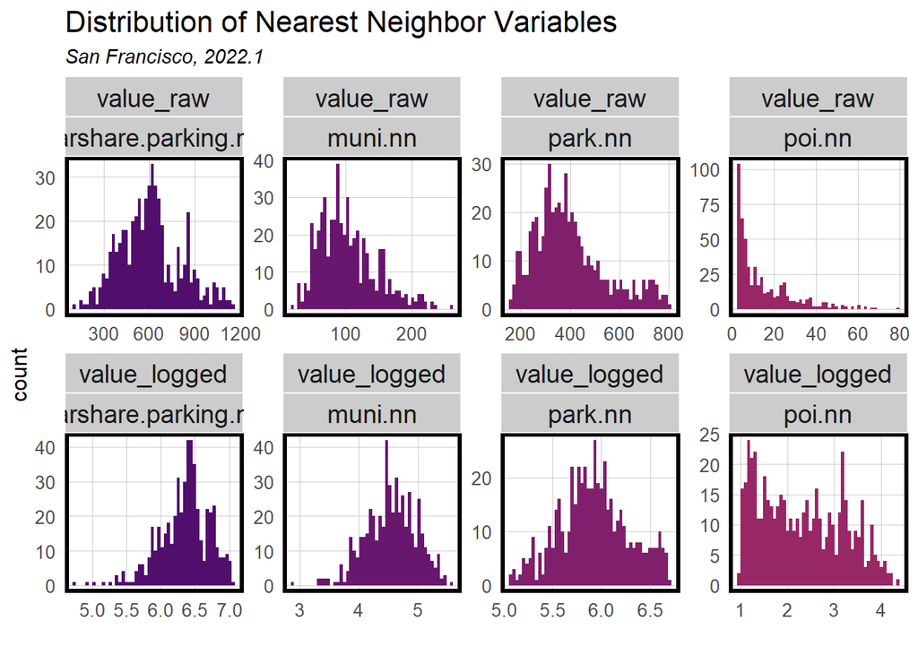

```r
spatial_features %>%
  pivot_longer(cols=ends_with(".nn"), names_to="name1", values_to="value_raw")%>%
  mutate(value_logged = log(value_raw))%>%
  pivot_longer(cols=starts_with("value"), names_to="if_log", values_to="name_log")%>%
  mutate(across(if_log, factor, levels=c("value_raw","value_logged"))) %>%
  ggplot() +
    geom_histogram(aes(name_log,fill=name1), bins=50)+
    scale_fill_manual(values=inferno(18)[5:11], guide=F)+
    facet_wrap(if_log~name1,scales = "free", nrow=2)+
    plotTheme()+
    labs(title='Distribution of Nearest Neighbor Variables',
         subtitle = 'San Francisco, 2022.1', x="")
```

#### Time Lag

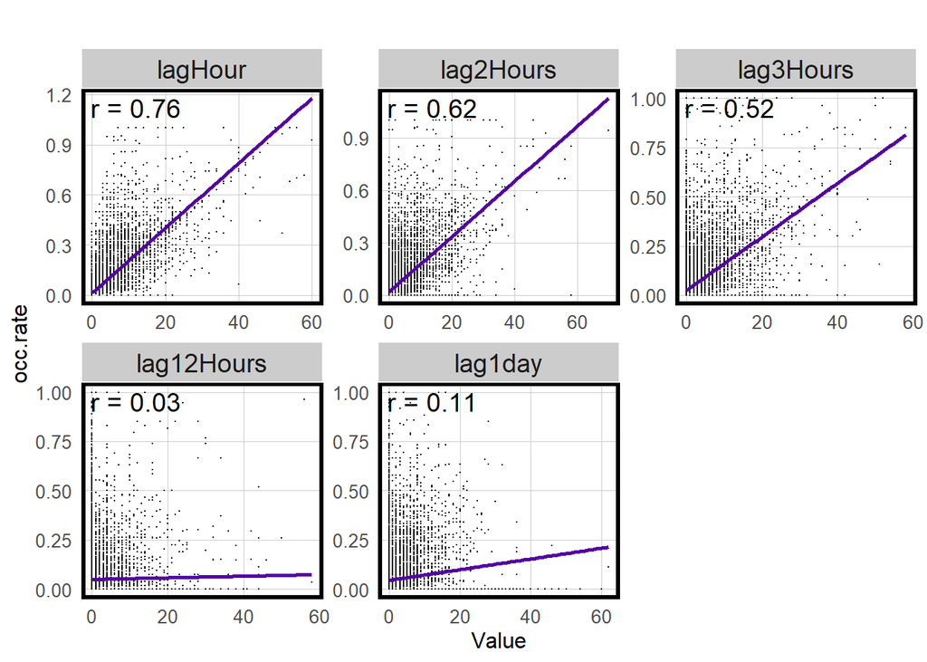

```r
plotData.lag <-
  as.data.frame(panel)%>%
  dplyr::select(starts_with("lag"), occ.rate) %>%
  gather(Variable, Value, -occ.rate) %>%
  mutate(Variable = fct_relevel(Variable, "lagHour","lag2Hours","lag3Hours",
                                "lag4Hours","lag12Hours","lag1day"))
correlation.lag <-
  group_by(plotData.lag, Variable) %>%
  summarize(correlation = round(cor(Value, occ.rate, use = "complete.obs"), 2))

plotData.lag %>% sample_n(100000)%>%
ggplot(aes(Value, occ.rate)) +
  geom_point(size = 0.1) +
  geom_text(data = correlation.lag,
            aes(label = paste("r =", round(correlation, 2))),
            x=-Inf, y=Inf, vjust = 1.5, hjust = -.1,size=5) +
  geom_smooth(method = "lm", se = FALSE, color = plasma(8)[2]) +
  facet_wrap(~Variable, nrow = 2, scales = "free") +
  labs(title = "") +
  plotTheme()
```

#### Price Area

Each street segment is joined to the parking rate area. We are looking at this categorical variable since drivers usually can estimate the range of parking prices based on geography or past experiences of parking in the area. In particular,

- Area 1 - Downtown primarily $3.50
- Area 2 - Surrounding downtown primarily $3.00
- Area 3 - Residential neighborhood primarily $2.00
- MC1 - Motorcycle in Area 1 primarily $0.70
- MC2 - Motorcycle in Area 2 primarily $0.60
- MC3 - Motorcycle in Area 3 primarily $0.40
- Port 7 - Port‐owned at Downtown $3.00
- Port 8 - Port‐owned at Downtown $3.00

From the bar plot of mean occupancy rate by rate area, we can see that high occupancy is related to low priced area especially when comparing the mean occupancy rate of Area 1-3.

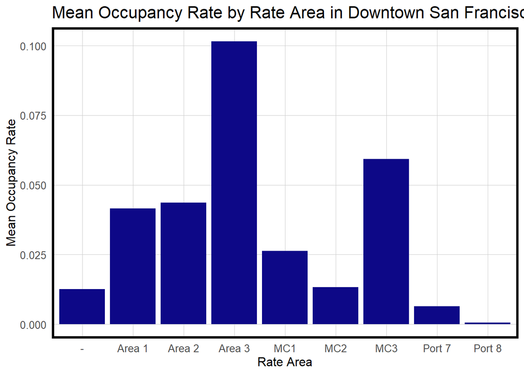

```r
rate_plot_tbl <- panel %>%
  group_by(rate_area) %>%
  summarize(mean_occupancy_rate = mean(occ.rate))

ggplot(data=rate_plot_tbl, aes(x = rate_area, y = mean_occupancy_rate)) +
  geom_bar(stat="identity", fill = plasma(8)[1]) +
  labs(x = "Rate Area", y="Mean Occupancy Rate", title = "Mean Occupancy Rate by Rate Area in Downtown San Francisco") +
  plotTheme()
```

## 4. Modeling and Cross-Validation

Regression 1: weather, rate area

Regression 3: weather, rate area, spatial features, temporal features

Regression 4: weather, rate area, spatial features, temporal features, time lag features

After training the model with the first three weeks of trips data, we will predict ridership with the data of last weeks and calculate the errors respectively.

```r
panel.train <- panel %>% filter(week < 4)
panel.test <- panel %>% filter(week == 4)

# reg <- glm(total_occupancy ~  st_type + hour(start_interval) + speedlimit + park.nn + carshare.parking.nn + poi.nn + units + sidewalk_f +lagHour,  data=panel, family = poisson())

f1 <- occ.rate ~  Temperature + Precipitation + Wind_Speed + rate_area
f2 <- occ.rate ~  st_type + speedlimit + park.nn.log + carshare.parking.nn + poi.nn.log + muni.nn + units + sidewalk_f + Temperature + Precipitation + Wind_Speed + rate_area
f3 <- occ.rate ~  st_type + hour(start_interval) + speedlimit + park.nn.log + carshare.parking.nn + poi.nn.log + muni.nn + units + sidewalk_f + Temperature + Precipitation + Wind_Speed + wday + rate_area
f4 <- occ.rate ~  st_type + hour(start_interval) + speedlimit + park.nn.log + carshare.parking.nn + poi.nn.log + muni.nn + units + sidewalk_f +lagHour + lag2Hours + lag3Hours + lag12Hours + lag1day + wday + Temperature + Precipitation + Wind_Speed + rate_area

reg1 <- lm(f1,  data=panel.train)
reg2 <- lm(f1,  data=panel.train)
reg3 <- lm(f3,  data=panel.train)
reg4 <- lm(f4,  data=panel.train)
reg5 <- glm(f4,  data=panel.train, family = poisson())


model_pred <- function(dat, fit){
   pred <- predict(fit, newdata = dat)}

panel.test.weekNest <-
  panel.test %>%
  nest(-week)

week_predictions <-
  panel.test.weekNest %>%
    mutate(Weather_model = map(.x = data, fit = reg1, .f = model_pred),
           Weather_Space_model = map(.x = data, fit = reg2, .f = model_pred),
           Weather_Space_Time_model = map(.x = data, fit = reg3, .f = model_pred),
           Weather_Space_Time_Lag_model = map(.x = data, fit = reg4, .f = model_pred),
           Weather_Space_Time_Lag_model = map(.x = data, fit = reg4, .f = model_pred))

mean.na = function(x) {mean(x,na.rm=T)}
sd.na = function(x) {sd(x,na.rm=T)}
week_predictions

week_predictions <- week_predictions %>%
    gather(Regression, Prediction, -data, -week) %>%
    mutate(Observed = map(data, pull, occ.rate),
           Absolute_Error = map2(Observed, Prediction,  ~ abs(.x - .y)),
           MAE = map_dbl(Absolute_Error, mean.na),
           sd_AE = map_dbl(Absolute_Error, sd.na))
```

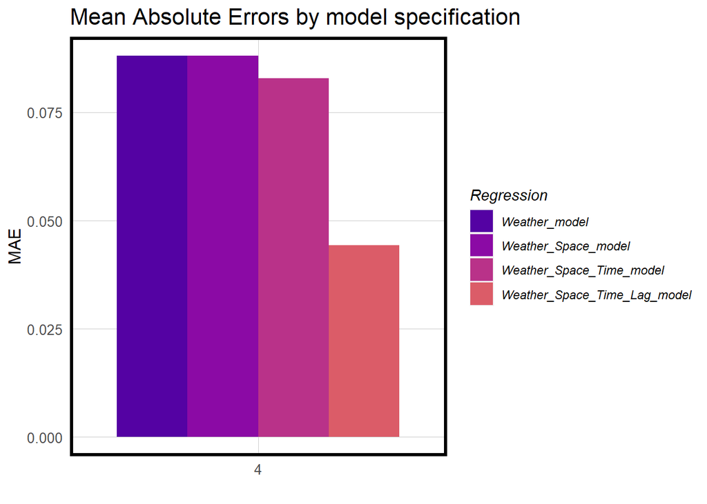

```r
week_predictions %>%
  dplyr::select(week, Regression, MAE) %>%
  gather(Variable, MAE, -Regression, -week) %>%
  mutate(
    across(Regression,factor,levels=c("Weather_model","Weather_Space_model","Weather_Space_Time_model",
                                    "Weather_Space_Time_Lag_model"))
  )%>%
  ggplot(aes(week%>%as.factor(), MAE)) +
    geom_bar(aes(fill = Regression), position = "dodge", stat="identity") +
    scale_fill_manual(values = plasma(8)[2:6]) +
    labs(title = "Mean Absolute Errors by model specification", x="") +
  plotTheme()
```

In particular, the p-value of the categorical variables of rate area are statistically significant in our model, showing statistical significance in predicting parking occupancy rate. This means that an adjusted pricing scheme based on demand is likely to be useful in controlling occupancy rate to an ideal range.

[interactive chart not shown]

Spatial errors of our best model show cluster in a few street segments but are otherwise distributed throughout with low MAE. Based on the result, the model will be quite useful for SFMTA to predict parking demand and adjusting parking rates accordingly.

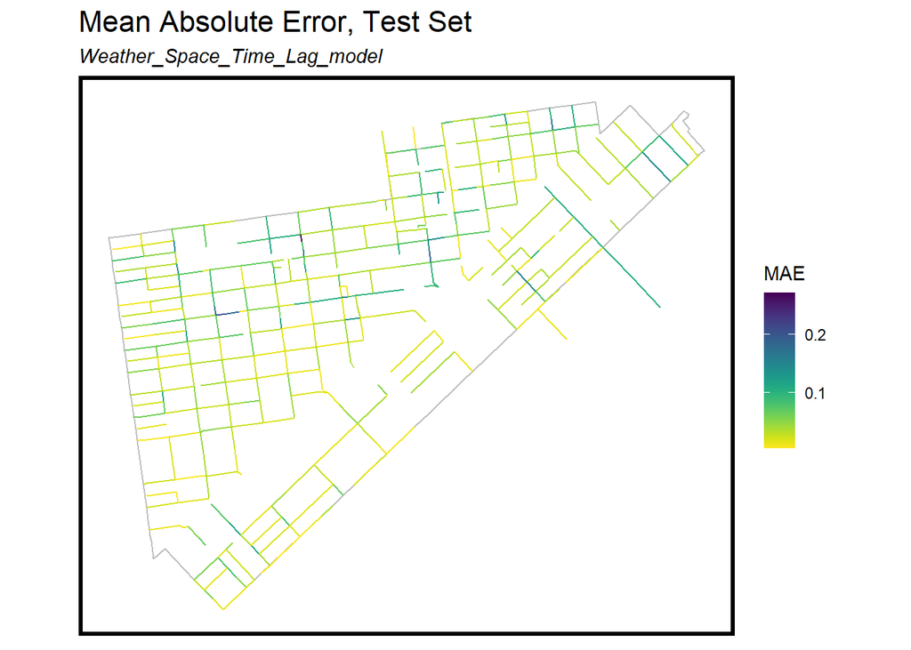

```r
spatial_error<- week_predictions %>%
    mutate(start_interval = map(data, pull, start_interval),
           ST_ID = map(data, pull, ST_ID)) %>%
    dplyr::select(start_interval, ST_ID, Observed, Prediction, Regression) %>%
    unnest(c(start_interval, ST_ID, Observed, Prediction)) %>%
  filter(Regression == "Weather_Space_Time_Lag_model") %>%
  group_by(ST_ID) %>%
  summarize(MAE = mean(abs(Observed-Prediction), na.rm = TRUE)) %>%
  as.data.frame()

ggplot()+
  geom_sf(data = district, color = "grey", fill = "transparent")+
  geom_sf(data= merge(street %>% dplyr::select(ST_ID), spatial_error, by="ST_ID"),
        aes(color=MAE),
        stroke = .5, shape = 16) +
  scale_colour_viridis(direction = -1,
  discrete = FALSE, option = "D")+
  labs(title="Mean Absolute Error, Test Set", subtitle="Weather_Space_Time_Lag_model")+
  mapTheme()
```

To further test the generalizability of the best model, we perform a random k-fold cross validation. The idea is to hold out one subset of data, train the model on the remaining data, predict for the hold out, and record the goodness of fit. The histogram of MAE generated by cross validation shows that the model has mostly very small errors around 3.75% across folds, indicating good generalizability.

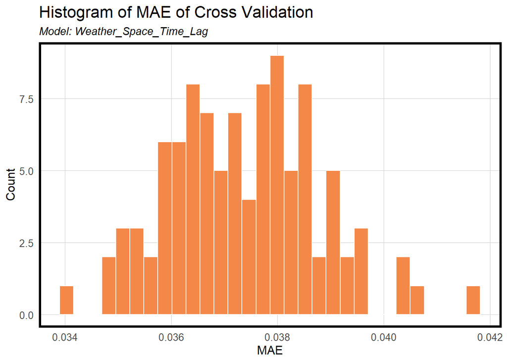

```r
fitControl <- trainControl(method = "cv", number = 100)
set.seed(26)
reg.cv = train(occ.rate ~  st_type + hour(start_interval) + speedlimit + park.nn.log + carshare.parking.nn + poi.nn.log + muni.nn + units + sidewalk_f +lagHour + lag2Hours + lag3Hours + lag12Hours + lag1day + wday + Temperature + Precipitation + Wind_Speed + rate_area,  data=panel.train,
     method = "lm", trControl = fitControl, na.action = na.pass)


MAE4 <- reg.cv$resample
ggplot(MAE4, aes(x=MAE)) +
  geom_histogram(color="white", fill = plasma(8)[6]) +
  labs(title = "Histogram of MAE of Cross Validation", subtitle = "Model: Weather_Space_Time_Lag",  x = "MAE", y= "Count") +
  plotTheme()
```

## 5. Conclusion

We have highlighted some areas where the model could be improved upon. One suggestion is to extend the time frame to reference a longer period of time. Currently, the model is only being trained on data from three weeks, which may not be enough to accurately predict parking demand patterns. By using data from a longer period of time, the model may be able to capture more nuanced patterns and make more accurate predictions.

We are also noted that San Francisco is a city with many special events, and the parking demand patterns may shift significantly during these events. This could make it difficult for the model to accurately predict demand during these times. To address this issue, it may be necessary to conduct more thorough exploratory analysis to better understand the impact of special events on parking demand.

Then we would suggest that it would be beneficial to include data from different seasons, as these can have an influence on travel patterns. By considering data from multiple seasons, the model may be able to better account for seasonal variations in demand and make more accurate predictions.

We would also like to point out that the model is currently only trained on data from the downtown area of San Francisco, and that it has performed well within this reference region. However, it also notes that in order for the model to be applicable in actual operation, it will be necessary to expand the training areas to include more data from other regions. By including more training data from a variety of areas, the model will be better able to generalize and make accurate predictions in larger San Francisco areas.

Lastly, the model currently calculates occupancy rates based on hourly data, and that it could be improved by increasing the granularity of this calculation. By doing so, the model will be able to provide more insights into how parking demand in San Francisco changes over time. One way to increase the granularity of the calculation would be to use data at a finer time resolution, such as data collected every 15 minutes or every 30 minutes. This would allow the model to capture more detailed patterns in parking demand.

We would recommend our model to SFMTA to use in its downtown, where most of their on-street parking spots are, for parking prediction. It has achieved great accuracy within our reference time and space and would be a great platform to keep improving on. More data from the SFMTA will be needed to keep building the independent variables to make the model correlates stronger with actual demand.